# EDA y Modelado Predictivo: Mortalidad en Medellín (2012–2023)

# 2 Carga y Vista Preliminar del Dataset

## 2.1 Librerías

```r
library(readr)
library(dplyr)
library(tidyr)
library(ggplot2)
library(skimr)
library(knitr)
library(kableExtra)
library(scales)
library(forcats)
library(stringr)
```

## 2.2 Carga del Dataset

```r
df <- read_csv(
  "C:/Users/Usuario/Causas_de_Defuncion_Medellin/data/defunciones.csv",
  locale        = locale(encoding = "UTF-8"),
  show_col_types = FALSE
)
```

## 2.3 Dimensiones

```r
cat("Filas:    ", nrow(df), "\n")
```

```
## Filas:     145377
```

```r
cat("Columnas: ", ncol(df), "\n")
```

```
## Columnas:  26
```

> **Nota:** El dataset cuenta con aproximadamente 145.000 registros y 26 variables, lo que lo convierte en una fuente rica para análisis multidimensionales. La cantidad de registros garantiza robustez estadística en la mayoría de los cruces y desagregaciones que se realizarán a lo largo del análisis.

## 2.4 Primeras Filas

```r
df %>%
  head(10) %>%
  kable(caption = "Primeras 10 filas del dataset") %>%
  kable_styling(
    bootstrap_options = c("striped", "hover", "condensed"),
    full_width        = TRUE,
    font_size         = 11
  ) %>%
  scroll_box(width = "100%", height = "350px")
```

Primeras 10 filas del dataset

| NUM_FORMUL | COD_INST | NOM_INST | TIPO_DEFUN | FECHA_DEF | ANO | MES | SEXO | EST_CIVIL | EDAD | NIVEL_EDU | CODPTORE | CODMUNRE | COD_BARRIRES | SEG_SOCIAL | IDADMISALUD | IDCODADMI | IDCLASADMI | N_BAS1 | C_BAS1 | BARRIO_RES | COMUNA_RES | ETAREO_QUIN | EDAD_SIMPLE | NOM_667_OPS_GRUPO | NOM_667_OPS_SUBC |
| --- | --- | --- | --- | --- | --- | --- | --- | --- | --- | --- | --- | --- | --- | --- | --- | --- | --- | --- | --- | --- | --- | --- | --- | --- | --- |
| 1 | NA | NA | 2 | 02/01/2012 | 2012 | 01 | 1 | 9 | 4051 | 99 | 5 | 1 | 9999 | 1 | 1 | EPS037 | NUEVA EPS SA | EXPOSICION A FACTORES NO ESPECIFICADOS QUE CAUSAN OTRAS LESIONES Y LAS NO ESPECIFICADAS | X599 | Sin informacion | Sin informacion | 50-54 | 51 | Causas externas | Los demas accidentes |
| 2 | 050010214401 | EMPRESA SOCIAL DEL ESTADO HOSPITAL GENERAL DE MEDELLIN LUZ CASTRO DE GUTIERREZ | 2 | 02/01/2012 | 2012 | 01 | 1 | 5 | 4026 | 99 | 5 | 1 | 1404 | 2 | 2 | EPS020 | CAPRECOM - CAJA DE PREVISION SOCIAL DE COMUNICACIONES | PEATON LESIONADO EN ACCIDENTE DE TRANSITO NO ESPECIFICADO | V093 | Castropol | 14 El Poblado | 25-29 | 26 | Causas externas | Accidentes de transporte terrestre |
| 3 | 050010590901 | IPS UNIVERSIDA DE ANTIOQUIA IPS UNIVERSITARIA | 2 | 02/01/2012 | 2012 | 01 | 1 | 9 | 4065 | 99 | 5 | 1 | 402 | 1 | 1 | NA | CAFESALUD MEDICINA PREPAGADA S.A. | PEATON LESIONADO POR COLISION CON VEHICULO DE MOTOR DE DOS O TRES RUEDAS: ACCIDENTE DE TRANSITO | V021 | San Isidro | 04 Aranjuez | 65-69 | 65 | Causas externas | Accidentes de transporte terrestre |
| 4 | NA | NA | 2 | 02/01/2012 | 2012 | 01 | 1 | 9 | 4029 | 03 | 5 | 1 | 107 | 2 | 2 | NA | CAFESALUD MEDICINA PREPAGADA S.A. | AGRESION CON DISPARO DE OTRAS ARMAS DE FUEGO Y LAS NO ESPECIFICADAS: CALLES Y CARRETERAS | X954 | San Pablo | 01 Popular | 25-29 | 29 | Causas externas | Agresiones (homicidios) |
| 5 | NA | NA | 2 | 02/01/2012 | 2012 | 01 | 1 | 9 | 4032 | 05 | 5 | 1 | 710 | 1 | 1 | NA | COOMEVA S.A. - ENTIDAD PROMOTORA DE SALUD | LESION AUTOINFLIGIDA INTENCIONALMENTE POR DISPARO DE OTRAS ARMAS DE FUEGO Y LAS NO ESPECIFICADAS: CALLES Y CARRETERAS | X744 | López de Mesa | 07 Robledo | 30-34 | 32 | Causas externas | Lesiones auto infligidas intencionalmente |
| 6 | NA | NA | 2 | 03/01/2012 | 2012 | 01 | 1 | 5 | 4016 | 99 | 5 | 1 | 1306 | 1 | 1 | NA | CAFESALUD MEDICINA PREPAGADA S.A. | AGRESION CON DISPARO DE OTRAS ARMAS DE FUEGO Y LAS NO ESPECIFICADAS: CALLES Y CARRETERAS | X954 | La Pradera | 13 San Javier | 15-19 | 16 | Causas externas | Agresiones (homicidios) |
| 7 | 050010212601 | PROMOTORA MEDICA LAS AMERICAS S A | 2 | 04/01/2012 | 2012 | 01 | 1 | 6 | 4079 | 99 | 5 | 1 | 1105 | 1 | 1 | EPS010 | SUSALUD E.P.S. | PEATON LESIONADO EN ACCIDENTE DE TRANSITO NO ESPECIFICADO | V093 | Los Conquistadores | 11 Laureles | 75-79 | 79 | Causas externas | Accidentes de transporte terrestre |
| 8 | NA | NA | 2 | 04/01/2012 | 2012 | 01 | 1 | 9 | 4020 | 99 | 5 | 1 | 9999 | 5 | NA | Sin información | NA | AGRESION CON DISPARO DE OTRAS ARMAS DE FUEGO Y LAS NO ESPECIFICADAS: CALLES Y CARRETERAS | X954 | Sin informacion | Sin informacion | 20-24 | 20 | Causas externas | Agresiones (homicidios) |
| 9 | NA | NA | 2 | 01/01/2012 | 2012 | 01 | 1 | 5 | 4017 | 99 | 5 | 1 | 8000 | 5 | NA | Sin información | NA | AGRESION CON DISPARO DE OTRAS ARMAS DE FUEGO Y LAS NO ESPECIFICADAS: CALLES Y CARRETERAS | X954 | Cabecera San Antonio de Prado | 80 Corregimiento de San Antonio de Prado | 15-19 | 17 | Causas externas | Agresiones (homicidios) |
| 10 | 050010590901 | IPS UNIVERSIDA DE ANTIOQUIA IPS UNIVERSITARIA | 2 | 06/01/2012 | 2012 | 01 | 1 | 4 | 4094 | 99 | 5 | 1 | 1209 | 5 | NA | Sin información | NA | OTRAS CAIDAS EN EL MISMO NIVEL: LUGAR NO ESPECIFICADO | W189 | Santa Mónica | 12 La America | 90-94 | 94 | Causas externas | Caidas |

> En esta vista preliminar se observa la estructura general del dataset: variables de identificación del registro, fechas, datos sociodemográficos del fallecido y códigos de causa de muerte. Nótese que varias columnas contienen valores numéricos codificados que requerirán transformación antes de su interpretación.

## 2.5 Tipos de Variables

```r
glimpse(df)
```

```
## Rows: 145,377
## Columns: 26
## $ NUM_FORMUL        <dbl> 1, 2, 3, 4, 5, 6, 7, 8, 9, 10, 11, 12, 13, 14, 15, 1…
## $ COD_INST          <chr> NA, "050010214401", "050010590901", NA, NA, NA, "050…
## $ NOM_INST          <chr> NA, "EMPRESA SOCIAL DEL ESTADO HOSPITAL GENERAL DE M…
## $ TIPO_DEFUN        <dbl> 2, 2, 2, 2, 2, 2, 2, 2, 2, 2, 2, 2, 2, 2, 2, 2, 2, 2…
## $ FECHA_DEF         <chr> "02/01/2012", "02/01/2012", "02/01/2012", "02/01/201…
## $ ANO               <dbl> 2012, 2012, 2012, 2012, 2012, 2012, 2012, 2012, 2012…
## $ MES               <chr> "01", "01", "01", "01", "01", "01", "01", "01", "01"…
## $ SEXO              <dbl> 1, 1, 1, 1, 1, 1, 1, 1, 1, 1, 1, 1, 1, 1, 1, 2, 1, 1…
## $ EST_CIVIL         <dbl> 9, 5, 9, 9, 9, 5, 6, 9, 5, 4, 5, 5, 4, 5, 9, 5, 5, 4…
## $ EDAD              <dbl> 4051, 4026, 4065, 4029, 4032, 4016, 4079, 4020, 4017…
## $ NIVEL_EDU         <chr> "99", "99", "99", "03", "05", "99", "99", "99", "99"…
## $ CODPTORE          <dbl> 5, 5, 5, 5, 5, 5, 5, 5, 5, 5, 5, 5, 5, 5, 5, 5, 5, 5…
## $ CODMUNRE          <dbl> 1, 1, 1, 1, 1, 1, 1, 1, 1, 1, 1, 1, 1, 1, 1, 1, 1, 1…
## $ COD_BARRIRES      <chr> "9999", "1404", "402", "107", "710", "1306", "1105",…
## $ SEG_SOCIAL        <dbl> 1, 2, 1, 2, 1, 1, 1, 5, 5, 5, 1, 1, 5, 5, 5, 1, 9, 1…
## $ IDADMISALUD       <dbl> 1, 2, 1, 2, 1, 1, 1, NA, NA, NA, 1, 1, NA, NA, NA, 1…
## $ IDCODADMI         <chr> "EPS037", "EPS020", NA, NA, NA, NA, "EPS010", "Sin i…
## $ IDCLASADMI        <chr> "NUEVA EPS SA", "CAPRECOM - CAJA DE PREVISION SOCIAL…
## $ N_BAS1            <chr> "EXPOSICION A FACTORES NO ESPECIFICADOS QUE CAUSAN O…
## $ C_BAS1            <chr> "X599", "V093", "V021", "X954", "X744", "X954", "V09…
## $ BARRIO_RES        <chr> "Sin informacion", "Castropol", "San Isidro", "San P…
## $ COMUNA_RES        <chr> "Sin informacion", "14 El Poblado", "04 Aranjuez", "…
## $ ETAREO_QUIN       <chr> "50-54", "25-29", "65-69", "25-29", "30-34", "15-19"…
## $ EDAD_SIMPLE       <dbl> 51, 26, 65, 29, 32, 16, 79, 20, 17, 94, 28, 53, 52, …
## $ NOM_667_OPS_GRUPO <chr> "Causas externas", "Causas externas", "Causas extern…
## $ NOM_667_OPS_SUBC  <chr> "Los demas accidentes", "Accidentes de transporte te…
```

> La mayoría de las variables demográficas (`SEXO`, `EST_CIVIL`, `NIVEL_EDU`, `SEG_SOCIAL`) están codificadas como enteros, por lo que será necesaria su recodificación a etiquetas legibles. La variable `EDAD` también requiere un tratamiento especial dado su sistema de codificación de 4 dígitos. Las variables de texto como nombres de barrio, comuna e institución presentan tipología `chr`.

## 2.6 Resumen Estadístico General

```r
skim(df)
```

Data summary

| Name | df |
| --- | --- |
| Number of rows | 145377 |
| Number of columns | 26 |
| _______________________ |  |
| Column type frequency: |  |
| character | 15 |
| numeric | 11 |
| ________________________ |  |
| Group variables | None |

**Variable type: character**

| skim_variable | n_missing | complete_rate | min | max | empty | n_unique | whitespace |
| --- | --- | --- | --- | --- | --- | --- | --- |
| COD_INST | 11908 | 0.92 | 8 | 12 | 0 | 692 | 0 |
| NOM_INST | 11748 | 0.92 | 2 | 118 | 0 | 817 | 0 |
| FECHA_DEF | 0 | 1.00 | 9 | 10 | 0 | 3653 | 0 |
| MES | 0 | 1.00 | 1 | 2 | 0 | 21 | 0 |
| NIVEL_EDU | 0 | 1.00 | 1 | 2 | 0 | 23 | 0 |
| COD_BARRIRES | 0 | 1.00 | 3 | 37 | 0 | 386 | 0 |
| IDCODADMI | 5369 | 0.96 | 1 | 15 | 0 | 125 | 0 |
| IDCLASADMI | 5697 | 0.96 | 8 | 120 | 0 | 186 | 0 |
| N_BAS1 | 0 | 1.00 | 6 | 221 | 0 | 4051 | 0 |
| C_BAS1 | 0 | 1.00 | 3 | 4 | 0 | 2600 | 0 |
| BARRIO_RES | 0 | 1.00 | 5 | 39 | 0 | 323 | 0 |
| COMUNA_RES | 0 | 1.00 | 8 | 40 | 0 | 22 | 0 |
| ETAREO_QUIN | 0 | 1.00 | 3 | 26 | 0 | 28 | 0 |
| NOM_667_OPS_GRUPO | 0 | 1.00 | 15 | 53 | 0 | 8 | 0 |
| NOM_667_OPS_SUBC | 0 | 1.00 | 6 | 107 | 0 | 84 | 0 |

**Variable type: numeric**

| skim_variable | n_missing | complete_rate | mean | sd | p0 | p25 | p50 | p75 | p100 | hist |
| --- | --- | --- | --- | --- | --- | --- | --- | --- | --- | --- |
| NUM_FORMUL | 0 | 1.00 | 72689.00 | 41966.87 | 1 | 36345 | 72689 | 109033 | 145377 | ▇▇▇▇▇ |
| TIPO_DEFUN | 0 | 1.00 | 2.00 | 0.00 | 2 | 2 | 2 | 2 | 2 | ▁▁▇▁▁ |
| ANO | 0 | 1.00 | 2016.97 | 2.94 | 2012 | 2014 | 2017 | 2020 | 2021 | ▅▅▆▆▇ |
| SEXO | 0 | 1.00 | 1.48 | 0.50 | 1 | 1 | 1 | 2 | 3 | ▇▁▇▁▁ |
| EST_CIVIL | 0 | 1.00 | 5.02 | 1.81 | 1 | 4 | 5 | 6 | 9 | ▂▇▆▇▂ |
| EDAD | 0 | 1.00 | 4039.33 | 269.63 | 1 | 4058 | 4073 | 4084 | 9999 | ▁▁▇▁▁ |
| CODPTORE | 0 | 1.00 | 5.00 | 0.00 | 5 | 5 | 5 | 5 | 5 | ▁▁▇▁▁ |
| CODMUNRE | 0 | 1.00 | 1.00 | 0.00 | 1 | 1 | 1 | 1 | 1 | ▁▁▇▁▁ |
| SEG_SOCIAL | 0 | 1.00 | 1.65 | 1.20 | 1 | 1 | 1 | 2 | 9 | ▇▁▁▁▁ |
| IDADMISALUD | 5688 | 0.96 | 1.64 | 1.33 | 1 | 1 | 1 | 2 | 9 | ▇▁▁▁▁ |
| EDAD_SIMPLE | 27 | 1.00 | 69.04 | 82.94 | 0 | 58 | 73 | 84 | 8888 | ▇▁▁▁▁ |

> El resumen estadístico revela las distribuciones de las variables numéricas y la presencia de valores faltantes. Las variables categóricas codificadas muestran rangos reducidos que confirman su naturaleza discreta. Este panorama inicial orienta los pasos de limpieza y transformación que se abordan en la siguiente sección.

# 3 Calidad de los Datos

## 3.1 Valores Nulos

```r
nulos_detalle <- df %>%
  summarise(across(everything(), ~ sum(is.na(.)))) %>%
  pivot_longer(everything(),
               names_to  = "Variable",
               values_to = "Nulos") %>%
  mutate(
    Porcentaje  = round(Nulos / nrow(df) * 100, 2),
    Completitud = round(100 - Porcentaje, 2)
  ) %>%
  arrange(desc(Nulos))

nulos_detalle %>%
  kable(
    caption = "Valores nulos por variable",
    align   = c("l", "r", "r", "r")
  ) %>%
  kable_styling(
    bootstrap_options = c("striped", "hover", "condensed"),
    full_width        = FALSE
  ) %>%
  row_spec(which(nulos_detalle$Porcentaje > 30),
           background = "#ffe0e0") %>%
  row_spec(which(nulos_detalle$Porcentaje > 0 &
                 nulos_detalle$Porcentaje <= 30),
           background = "#fff8e1")
```

Valores nulos por variable

| Variable | Nulos | Porcentaje | Completitud |
| --- | --- | --- | --- |
| COD_INST | 11908 | 8.19 | 91.81 |
| NOM_INST | 11748 | 8.08 | 91.92 |
| IDCLASADMI | 5697 | 3.92 | 96.08 |
| IDADMISALUD | 5688 | 3.91 | 96.09 |
| IDCODADMI | 5369 | 3.69 | 96.31 |
| EDAD_SIMPLE | 27 | 0.02 | 99.98 |
| NUM_FORMUL | 0 | 0.00 | 100.00 |
| TIPO_DEFUN | 0 | 0.00 | 100.00 |
| FECHA_DEF | 0 | 0.00 | 100.00 |
| ANO | 0 | 0.00 | 100.00 |
| MES | 0 | 0.00 | 100.00 |
| SEXO | 0 | 0.00 | 100.00 |
| EST_CIVIL | 0 | 0.00 | 100.00 |
| EDAD | 0 | 0.00 | 100.00 |
| NIVEL_EDU | 0 | 0.00 | 100.00 |
| CODPTORE | 0 | 0.00 | 100.00 |
| CODMUNRE | 0 | 0.00 | 100.00 |
| COD_BARRIRES | 0 | 0.00 | 100.00 |
| SEG_SOCIAL | 0 | 0.00 | 100.00 |
| N_BAS1 | 0 | 0.00 | 100.00 |
| C_BAS1 | 0 | 0.00 | 100.00 |
| BARRIO_RES | 0 | 0.00 | 100.00 |
| COMUNA_RES | 0 | 0.00 | 100.00 |
| ETAREO_QUIN | 0 | 0.00 | 100.00 |
| NOM_667_OPS_GRUPO | 0 | 0.00 | 100.00 |
| NOM_667_OPS_SUBC | 0 | 0.00 | 100.00 |

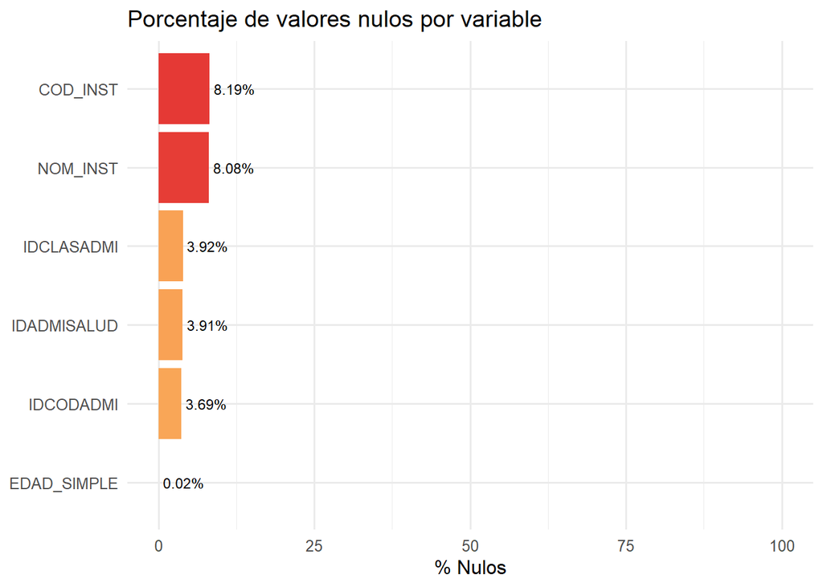

```r
nulos_detalle %>%
  filter(Nulos > 0) %>%
  ggplot(aes(x = reorder(Variable, Porcentaje), y = Porcentaje,
             fill = Porcentaje)) +
  geom_col(show.legend = FALSE) +
  geom_text(aes(label = paste0(Porcentaje, "%")),
            hjust = -0.1, size = 3.2) +
  scale_fill_gradient(low = "#fff176", high = "#e53935") +
  coord_flip() +
  ylim(0, 100) +
  labs(
    title = "Porcentaje de valores nulos por variable",
    x     = NULL,
    y     = "% Nulos"
  ) +
  theme_minimal(base_size = 12)
```

> Solo 6 variables presentan valores nulos. `COD_INST` y `NOM_INST` tienen la mayor nulidad (~8%), probablemente por defunciones ocurridas fuera de una institución de salud. Las demás variables no superan el 4%. En general, la calidad del dataset es alta.

## 3.2 Duplicados

```r
dup_filas <- sum(duplicated(df))
cat("Filas completamente duplicadas:", dup_filas, "\n")
```

```
## Filas completamente duplicadas: 0
```

```r
dup_formul <- df %>%
  filter(!is.na(NUM_FORMUL)) %>%
  count(NUM_FORMUL) %>%
  filter(n > 1)

cat("NUM_FORMUL repetidos:", nrow(dup_formul), "\n")
```

```
## NUM_FORMUL repetidos: 0
```

> La revisión de duplicados es un paso crítico para evitar inflar conteos. Si el número de filas completamente duplicadas es bajo o cero, el dataset tiene buena integridad. Los `NUM_FORMUL` repetidos pueden indicar registros administrativos del mismo fallecimiento en distintas instancias; se recomienda conservar solo el registro más completo en esos casos antes de análisis cuantitativos.

## 3.3 Corrección de Tipos de Datos

### 3.3.1 Fecha de defunción

```r
df <- df %>%
  mutate(FECHA_DEF = as.Date(FECHA_DEF, format = "%d/%m/%Y"))

cat("Rango de fechas:\n")
```

```
## Rango de fechas:
```

```r
cat("  Desde:", format(min(df$FECHA_DEF, na.rm = TRUE)), "\n")
```

```
##   Desde: 2012-01-01
```

```r
cat("  Hasta:", format(max(df$FECHA_DEF, na.rm = TRUE)), "\n")
```

```
##   Hasta: 2021-12-31
```

> La conversión de la fecha a tipo `Date` permite realizar operaciones temporales como extraer año, mes o calcular diferencias. El rango resultante debe coincidir con el período declarado (2012–2023); cualquier fecha fuera de ese rango representaría un error de registro que debería investigarse.

### 3.3.2 Transformación de EDAD

La variable `EDAD` original usa una codificación especial de 4 dígitos: el primer dígito indica la **unidad de tiempo** y los tres siguientes el **valor**. Por ejemplo `4051` significa 51 años, `3007` significa 7 meses, `2015` significa 15 días.

| Primer dígito | Unidad | Ejemplo | Interpretación |
| --- | --- | --- | --- |
| 1 | Horas | `1005` | 5 horas |
| 2 | Días | `2015` | 15 días |
| 3 | Meses | `3007` | 7 meses |
| 4 | Años | `4051` | 51 años |

```r
df <- df %>%
  mutate(
    EDAD_UNIDAD = as.integer(substr(as.character(EDAD), 1, 1)),
    EDAD_VALOR  = as.integer(substr(as.character(EDAD), 2, 4)),
    EDAD_ANIOS  = case_when(
      EDAD_UNIDAD == 4 ~ EDAD_VALOR,
      EDAD_UNIDAD == 3 ~ 0,
      EDAD_UNIDAD == 2 ~ 0,
      EDAD_UNIDAD == 1 ~ 0,
      TRUE             ~ NA_real_
    )
  )

cat("Rango de edad en años:\n")
```

```
## Rango de edad en años:
```

```r
cat("  Mínimo:", min(df$EDAD_ANIOS, na.rm = TRUE), "\n")
```

```
##   Mínimo: 0
```

```r
cat("  Máximo:", max(df$EDAD_ANIOS, na.rm = TRUE), "\n")
```

```
##   Máximo: 999
```

> La estandarización de la edad en años facilita comparaciones directas entre registros. Los fallecidos con unidades distintas a años (horas, días, meses) son clasificados como 0 años, lo que agrupa neonatos e infantes en la misma categoría. Si el máximo supera los 120 años, esos valores deberían revisarse como posibles errores de registro.

### 3.3.3 Variables categóricas

```r
df <- df %>%
  mutate(
    SEXO = case_when(
      SEXO == 1 ~ "Masculino",
      SEXO == 2 ~ "Femenino",
      TRUE      ~ "Sin información"
    ),
    TIPO_DEFUN = case_when(
      TIPO_DEFUN == 1 ~ "Natural",
      TIPO_DEFUN == 2 ~ "No natural",
      TIPO_DEFUN == 3 ~ "En estudio",
      TRUE            ~ "Sin información"
    ),
    EST_CIVIL = case_when(
      EST_CIVIL == 1 ~ "Unión libre estable",
      EST_CIVIL == 2 ~ "Unión libre reciente",
      EST_CIVIL == 3 ~ "Separado/a",
      EST_CIVIL == 4 ~ "Viudo/a",
      EST_CIVIL == 5 ~ "Soltero/a",
      EST_CIVIL == 6 ~ "Casado/a",
      EST_CIVIL == 9 ~ "Sin información",
      TRUE           ~ "Sin información"
    ),
    SEG_SOCIAL = case_when(
      SEG_SOCIAL == 1 ~ "Contributivo",
      SEG_SOCIAL == 2 ~ "Subsidiado",
      SEG_SOCIAL == 3 ~ "Vinculado",
      SEG_SOCIAL == 4 ~ "Particular",
      SEG_SOCIAL == 5 ~ "Excepción",
      SEG_SOCIAL == 6 ~ "Indígena",
      TRUE            ~ "Sin información"
    ),
    NIVEL_EDU = case_when(
      NIVEL_EDU == 1  ~ "Preescolar",
      NIVEL_EDU == 2  ~ "Básica primaria",
      NIVEL_EDU == 3  ~ "Básica secundaria",
      NIVEL_EDU == 4  ~ "Media académica",
      NIVEL_EDU == 5  ~ "Media técnica",
      NIVEL_EDU == 6  ~ "Normalista",
      NIVEL_EDU == 7  ~ "Técnica profesional",
      NIVEL_EDU == 8  ~ "Tecnológica",
      NIVEL_EDU == 9  ~ "Profesional",
      NIVEL_EDU == 10 ~ "Especialización",
      NIVEL_EDU == 11 ~ "Maestría",
      NIVEL_EDU == 12 ~ "Doctorado",
      NIVEL_EDU == 99 ~ "Sin información",
      TRUE            ~ "Sin información"
    )
  )
```

> La recodificación de las variables categóricas transforma etiquetas numéricas en categorías legibles, lo que es indispensable para la correcta interpretación de los gráficos y tablas posteriores. El uso de `TRUE ~ "Sin información"` como categoría de fallback captura códigos no documentados o valores inesperados, preservando la integridad del análisis.

### 3.3.4 Tratamiento de ETAREO_QUIN

Excel convierte automáticamente ciertos rangos etarios con guión a formato fecha al abrir el CSV (por ejemplo, `"10-14"` se guarda como `"oct-14"`, `"1-4"` como `"1-abr"`, `"5-9"` como `"5-sep"`). Es necesario revertir esta corrupción y convertir a `NA` los valores que no corresponden a rangos quinquenales válidos.

```r
df <- df %>%
  mutate(
    ETAREO_QUIN = case_when(
      ETAREO_QUIN == "oct-14"  ~ "10-14",
      ETAREO_QUIN == "1-abr"   ~ "1-4",
      ETAREO_QUIN == "5-sep"   ~ "5-9",
      ETAREO_QUIN %in% c("Sin informacion",
                          "Sin información",
                          "Edad desconocida",
                          "Mayor de 2 años y sin inf.") ~ NA_character_,
      TRUE ~ ETAREO_QUIN
    )
  )

cat("Distribución corregida de ETAREO_QUIN:\n")
```

```
## Distribución corregida de ETAREO_QUIN:
```

```r
df %>%
  count(ETAREO_QUIN, sort = TRUE) %>%
  print(n = 30)
```

```
## # A tibble: 23 × 2
##    ETAREO_QUIN     n
##    <chr>       <int>
##  1 80-84       17927
##  2 85-89       17052
##  3 75-79       16206
##  4 70-74       14462
##  5 65-69       12820
##  6 90-94       11404
##  7 60-64       10919
##  8 55-59        8546
##  9 50-54        6032
## 10 95-99        4831
## 11 45-49        4063
## 12 30-34        3014
## 13 25-29        3008
## 14 40-44        2992
## 15 35-39        2901
## 16 20-24        2841
## 17 < 1 año      2162
## 18 15-19        1809
## 19 100 y mas    1256
## 20 10-14         433
## 21 1-4           385
## 22 5-9           275
## 23 <NA>           39
```

> La corrección de la corrupción por Excel es un paso crítico: sin ella, los grupos `"10-14"`, `"1-4"` y `"5-9"` quedan ausentes de los análisis, sesgando los patrones de mortalidad infantil y adolescente. Tras la corrección, la distribución quinquenal es completa y coherente con el total de registros.

### 3.3.5 Tratamiento de EDAD_SIMPLE

La variable `EDAD_SIMPLE` contiene valores centinela (`8888`, `4000`, `4999`) que codifican edad desconocida o inválida, y deben ser reemplazados por `NA` antes del análisis numérico.

```r
df <- df %>%
  mutate(
    EDAD_SIMPLE = as.numeric(EDAD_SIMPLE),
    EDAD_SIMPLE = if_else(EDAD_SIMPLE %in% c(8888, 4000, 4999), NA_real_, EDAD_SIMPLE)
  )

cat("Resumen de EDAD_SIMPLE tras limpieza:\n")
```

```
## Resumen de EDAD_SIMPLE tras limpieza:
```

```r
summary(df$EDAD_SIMPLE)
```

```
##    Min. 1st Qu.  Median    Mean 3rd Qu.    Max.    NA's
##    0.00   58.00   73.00   68.31   84.00  116.00      39
```

```r
cat("\nFaltantes:", sum(is.na(df$EDAD_SIMPLE)),
    " | Proporción:", round(mean(is.na(df$EDAD_SIMPLE)) * 100, 2), "%\n")
```

```
##
## Faltantes: 39  | Proporción: 0.03 %
```

> Antes de la limpieza, el máximo podía superar 8000 años. Tras eliminar los centinelas, el rango queda en valores biológicamente plausibles (0–116 años), con menos del 0.03% de faltantes, lo que garantiza robustez estadística en los análisis de distribución de edad.

### 3.3.6 Unificación de NOM_667_OPS_GRUPO

En el dataset coexisten dos versiones del mismo grupo: `"Signos, sintomas y afecciones mal definidas"` (con coma) y `"Signos sintomas y afecciones mal definidas"` (sin coma). Se unifican en una sola etiqueta.

```r
df <- df %>%
  mutate(
    NOM_667_OPS_GRUPO = stringr::str_replace(
      NOM_667_OPS_GRUPO, "Signos, sintomas", "Signos sintomas"
    ),
    NOM_667_OPS_GRUPO = stringr::str_trim(NOM_667_OPS_GRUPO)
  )

cat("Categorías finales de NOM_667_OPS_GRUPO:\n")
```

```
## Categorías finales de NOM_667_OPS_GRUPO:
```

```r
df %>% count(NOM_667_OPS_GRUPO, sort = TRUE) %>% print()
```

```
## # A tibble: 7 × 2
##   NOM_667_OPS_GRUPO                                         n
##   <chr>                                                 <int>
## 1 Enfermedades del sistema circulatorio                 41337
## 2 Neoplasias (Tumores)                                  34857
## 3 Todas las demas enfermedades                          33785
## 4 Enfermedades Transmisibles                            19070
## 5 Causas externas                                       14462
## 6 Ciertas afecciones originadas en el periodo perinatal  1121
## 7 Signos sintomas y afecciones mal definidas              745
```

> La duplicidad de categorías inflaba artificialmente el recuento de “mal definidas” y podía fragmentar visualizaciones. Tras la unificación hay exactamente 7 grupos OPS limpios, coherentes con la clasificación oficial.

### 3.3.7 Nivel educativo agrupado (NIVEL_EDU_GRUPO)

Para facilitar los análisis bivariados se crea una versión agrupada del nivel educativo en cuatro categorías: **Básica**, **Media**, **Técnico/Tecnológico** y **Superior**.

```r
df <- df %>%
  mutate(
    NIVEL_EDU_GRUPO = case_when(
      NIVEL_EDU %in% c("Preescolar",
                        "Básica primaria",
                        "Básica secundaria")          ~ "Básica",
      NIVEL_EDU %in% c("Media académica",
                        "Media técnica")              ~ "Media",
      NIVEL_EDU %in% c("Normalista",
                        "Técnica profesional",
                        "Tecnológica")                ~ "Técnico/Tecnológico",
      NIVEL_EDU %in% c("Profesional",
                        "Especialización",
                        "Maestría",
                        "Doctorado")                  ~ "Superior",
      TRUE                                            ~ "Sin información"
    ),
    NIVEL_EDU_GRUPO = factor(
      NIVEL_EDU_GRUPO,
      levels = c("Básica", "Media", "Técnico/Tecnológico",
                 "Superior", "Sin información")
    )
  )

df %>%
  count(NIVEL_EDU_GRUPO) %>%
  mutate(Porcentaje = round(n / sum(n) * 100, 2)) %>%
  kable(
    caption   = "Distribución por nivel educativo agrupado",
    col.names = c("Grupo educativo", "Defunciones", "Porcentaje (%)"),
    align     = c("l", "r", "r")
  ) %>%
  kable_styling(bootstrap_options = c("striped", "hover"), full_width = FALSE)
```

Distribución por nivel educativo agrupado

| Grupo educativo | Defunciones | Porcentaje (%) |
| --- | --- | --- |
| Básica | 29922 | 20.58 |
| Media | 4023 | 2.77 |
| Técnico/Tecnológico | 1478 | 1.02 |
| Superior | 3449 | 2.37 |
| Sin información | 106505 | 73.26 |

> El nivel **Básica** concentra la mayor parte de los fallecidos, coherente con la estructura etaria de la mortalidad (personas mayores con menor escolaridad histórica). Los grupos **Superior** y **Técnico/Tecnológico** tienen representación minoritaria pero son útiles para análisis de inequidad en salud.

## 3.4 Valores Especiales Codificados

```r
especiales <- tibble::tribble(
  ~Variable,      ~Valor_centinela, ~Conteo,
  "NIVEL_EDU",    "99",   sum(df$NIVEL_EDU    == "Sin información", na.rm = TRUE),
  "EST_CIVIL",    "9",    sum(df$EST_CIVIL     == "Sin información", na.rm = TRUE),
  "COD_BARRIRES", "9999", sum(df$COD_BARRIRES  == 9999,             na.rm = TRUE),
  "CODPTORE",     "99",   sum(df$CODPTORE      == 99,               na.rm = TRUE)
)

especiales %>%
  mutate(Porcentaje = round(Conteo / nrow(df) * 100, 2)) %>%
  kable(
    caption = "Valores centinela (codifican Sin información)",
    align   = c("l", "l", "r", "r")
  ) %>%
  kable_styling(bootstrap_options = c("striped", "hover"), full_width = FALSE)
```

Valores centinela (codifican Sin información)

| Variable | Valor_centinela | Conteo | Porcentaje |
| --- | --- | --- | --- |
| NIVEL_EDU | 99 | 106505 | 73.26 |
| EST_CIVIL | 9 | 13311 | 9.16 |
| COD_BARRIRES | 9999 | 3291 | 2.26 |
| CODPTORE | 99 | 0 | 0.00 |

> Los valores centinela son códigos que en apariencia son numéricos válidos pero en realidad representan ausencia de información. Su identificación es clave para no incluirlos en cálculos estadísticos. En particular, `NIVEL_EDU == 99` suele tener alta frecuencia en registros de personas mayores, donde la educación formal no fue completamente registrada por el notificador.

## 3.5 Dataset Limpio — Resumen Final

```r
cat("Dimensiones finales del dataset limpio:\n")
```

```
## Dimensiones finales del dataset limpio:
```

```r
cat("  Filas:    ", nrow(df), "\n")
```

```
##   Filas:     145377
```

```r
cat("  Columnas: ", ncol(df), "\n\n")
```

```
##   Columnas:  30
```

```r
cat("Variables nuevas creadas en la limpieza:\n")
```

```
## Variables nuevas creadas en la limpieza:
```

```r
cat("  - EDAD_UNIDAD      : unidad de tiempo de la edad original\n")
```

```
##   - EDAD_UNIDAD      : unidad de tiempo de la edad original
```

```r
cat("  - EDAD_VALOR       : valor numérico de la edad original\n")
```

```
##   - EDAD_VALOR       : valor numérico de la edad original
```

```r
cat("  - EDAD_ANIOS       : edad estandarizada en años\n")
```

```
##   - EDAD_ANIOS       : edad estandarizada en años
```

```r
cat("  - NIVEL_EDU_GRUPO  : nivel educativo agrupado (Básica/Media/Técnico/Superior)\n")
```

```
##   - NIVEL_EDU_GRUPO  : nivel educativo agrupado (Básica/Media/Técnico/Superior)
```

```r
cat("\nFaltantes clave tras limpieza:\n")
```

```
##
## Faltantes clave tras limpieza:
```

```r
cat("  - EDAD_SIMPLE  :", sum(is.na(df$EDAD_SIMPLE)), "faltantes\n")
```

```
##   - EDAD_SIMPLE  : 39 faltantes
```

```r
cat("  - ETAREO_QUIN  :", sum(is.na(df$ETAREO_QUIN)), "faltantes\n")
```

```
##   - ETAREO_QUIN  : 39 faltantes
```

> Tras las transformaciones realizadas, el dataset conserva la totalidad de los registros originales y se enriquece con variables derivadas: edad en años, nivel educativo agrupado, y las correcciones de centinelas en `EDAD_SIMPLE` y corrupción de Excel en `ETAREO_QUIN`. El dataset limpio constituye la base para todos los análisis que siguen.

## 3.6 Selección de Variables para el Análisis

### 3.6.1 Variables descartadas

De las 26 columnas originales se descartan las que no aportan valor analítico directo: identificadores administrativos, columnas con alta nulidad estructural y variables que quedan cubiertas por otras derivadas.

```r
vars_descartadas <- tibble::tribble(
  ~Variable,          ~Motivo,
  "NUM_FORMUL",        "Identificador administrativo sin valor analítico",
  "COD_INST",          "~8% nulos; nombre de institución cubre el análisis",
  "IDADMISALUD",       "Código interno del administrador, no interpretable",
  "IDCODADMI",         "Ídem",
  "IDCLASADMI",        "Ídem",
  "CODPTORE",          "Sin variabilidad: 100% Antioquia en este dataset",
  "COD_BARRIRES",      "Reemplazado por BARRIO_RES (texto legible)",
  "EDAD",              "Reemplazada por EDAD_ANIOS y EDAD_SIMPLE",
  "EDAD_UNIDAD",       "Variable auxiliar de decodificación",
  "EDAD_VALOR",        "Variable auxiliar de decodificación"
)

vars_descartadas %>%
  kable(caption = "Variables descartadas del análisis",
        align   = c("l", "l"),
        col.names = c("Variable", "Motivo")) %>%
  kable_styling(bootstrap_options = c("striped", "hover"), full_width = FALSE)
```

Variables descartadas del análisis

| Variable | Motivo |
| --- | --- |
| NUM_FORMUL | Identificador administrativo sin valor analítico |
| COD_INST | ~8% nulos; nombre de institución cubre el análisis |
| IDADMISALUD | Código interno del administrador, no interpretable |
| IDCODADMI | Ídem |
| IDCLASADMI | Ídem |
| CODPTORE | Sin variabilidad: 100% Antioquia en este dataset |
| COD_BARRIRES | Reemplazado por BARRIO_RES (texto legible) |
| EDAD | Reemplazada por EDAD_ANIOS y EDAD_SIMPLE |
| EDAD_UNIDAD | Variable auxiliar de decodificación |
| EDAD_VALOR | Variable auxiliar de decodificación |

### 3.6.2 Variables seleccionadas para el análisis

```r
vars_analisis <- c(
  "NOM_667_OPS_GRUPO",  # Variable objetivo / clasificadora principal
  "NOM_667_OPS_SUBC",   # Subcategoría OPS para drill-down
  "N_BAS1", "C_BAS1",   # Causa CIE-10 (nombre y código)
  "TIPO_DEFUN",         # Tipo de defunción
  "ANO", "MES",         # Temporales
  "SEXO",               # Demográfica
  "EDAD_SIMPLE",        # Edad numérica (limpia)
  "ETAREO_QUIN",        # Edad categórica quinquenal (corregida)
  "EST_CIVIL",          # Demográfica
  "SEG_SOCIAL",         # Régimen de seguridad social
  "NIVEL_EDU_GRUPO",    # Educación agrupada
  "NIVEL_EDU",          # Educación detallada
  "COMUNA_RES",         # Geográfica (nivel comuna)
  "BARRIO_RES",         # Geográfica (nivel barrio)
  "NOM_INST"            # Institución de defunción
)

vars_ok <- intersect(vars_analisis, names(df))

tibble(
  Variable = vars_ok,
  Tipo = sapply(df[vars_ok], class),
  Faltantes_pct = sapply(df[vars_ok], function(x)
    round(mean(is.na(x)) * 100, 2))
) %>%
  kable(
    caption   = "Variables seleccionadas para el análisis",
    col.names = c("Variable", "Tipo R", "% Faltantes"),
    align     = c("l", "l", "r")
  ) %>%
  kable_styling(bootstrap_options = c("striped", "hover"), full_width = FALSE)
```

Variables seleccionadas para el análisis

| Variable | Tipo R | % Faltantes |
| --- | --- | --- |
| NOM_667_OPS_GRUPO | character | 0.00 |
| NOM_667_OPS_SUBC | character | 0.00 |
| N_BAS1 | character | 0.00 |
| C_BAS1 | character | 0.00 |
| TIPO_DEFUN | character | 0.00 |
| ANO | numeric | 0.00 |
| MES | character | 0.00 |
| SEXO | character | 0.00 |
| EDAD_SIMPLE | numeric | 0.03 |
| ETAREO_QUIN | character | 0.03 |
| EST_CIVIL | character | 0.00 |
| SEG_SOCIAL | character | 0.00 |
| NIVEL_EDU_GRUPO | factor | 0.00 |
| NIVEL_EDU | character | 0.00 |
| COMUNA_RES | character | 0.00 |
| BARRIO_RES | character | 0.00 |
| NOM_INST | character | 8.08 |

# 4 Análisis Univariado

## 4.1 Variables Numéricas

### 4.1.1 Edad en años

```r
summary_edad <- df %>%
  summarise(
    Media   = round(mean(EDAD_ANIOS, na.rm = TRUE), 1),
    Mediana = median(EDAD_ANIOS, na.rm = TRUE),
    DE      = round(sd(EDAD_ANIOS, na.rm = TRUE), 1),
    Mínimo  = min(EDAD_ANIOS, na.rm = TRUE),
    Máximo  = max(EDAD_ANIOS, na.rm = TRUE)
  )

summary_edad %>%
  kable(
    caption = "Estadísticos descriptivos — Edad en años",
    align   = c("r", "r", "r", "r", "r")
  ) %>%
  kable_styling(bootstrap_options = c("striped", "hover"), full_width = FALSE)
```

Estadísticos descriptivos — Edad en años

| Media | Mediana | DE | Mínimo | Máximo |
| --- | --- | --- | --- | --- |
| 68.5 | 73 | 24.6 | 0 | 999 |

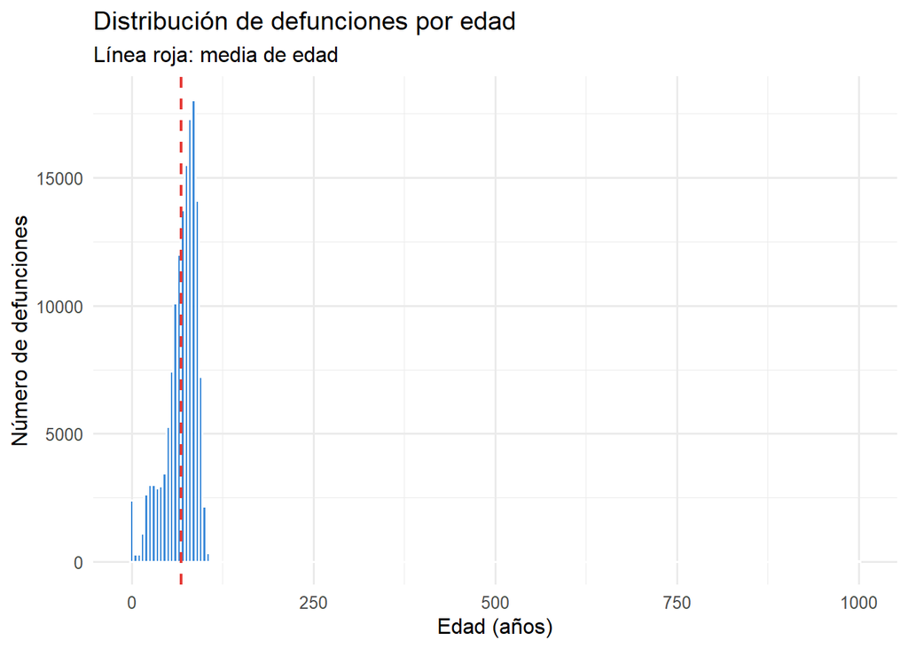

```r
df %>%
  filter(!is.na(EDAD_ANIOS)) %>%
  ggplot(aes(x = EDAD_ANIOS)) +
  geom_histogram(binwidth = 5, fill = "#1976D2", color = "white", alpha = 0.85) +
  geom_vline(aes(xintercept = mean(EDAD_ANIOS, na.rm = TRUE)),
             color = "#e53935", linetype = "dashed", linewidth = 0.8) +
  labs(
    title    = "Distribución de defunciones por edad",
    subtitle = "Línea roja: media de edad",
    x        = "Edad (años)",
    y        = "Número de defunciones"
  ) +
  theme_minimal(base_size = 12)
```

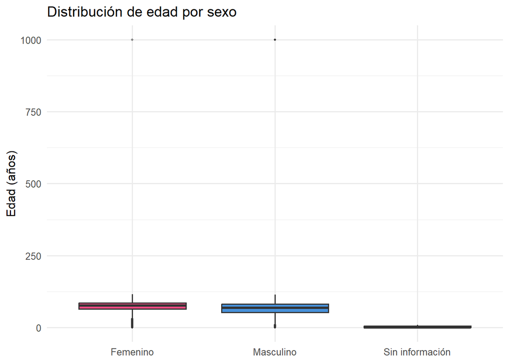

```r
df %>%
  filter(!is.na(EDAD_ANIOS), !is.na(SEXO)) %>%
  ggplot(aes(x = SEXO, y = EDAD_ANIOS, fill = SEXO)) +
  geom_boxplot(alpha = 0.8, outlier.alpha = 0.2, outlier.size = 0.8) +
  scale_fill_manual(values = c("Masculino"       = "#1976D2",
                               "Femenino"        = "#E91E63",
                               "Sin información" = "#9E9E9E")) +
  labs(
    title = "Distribución de edad por sexo",
    x     = NULL,
    y     = "Edad (años)"
  ) +
  theme_minimal(base_size = 12) +
  theme(legend.position = "none")
```

> La distribución de la edad al momento del fallecimiento presenta una marcada concentración en los grupos de mayor edad (60+ años), lo que es consistente con patrones de mortalidad en países de renta media con transición epidemiológica avanzada. El histograma muestra una distribución asimétrica a la izquierda con una cola hacia edades jóvenes, que corresponde principalmente a muertes violentas o neonatales. El boxplot por sexo revela que las mujeres tienden a fallecer a edades ligeramente mayores que los hombres, reflejando la mayor esperanza de vida femenina característica de la ciudad.

## 4.2 Variables Categóricas

### 4.2.1 Sexo

```r
df %>%
  count(SEXO) %>%
  mutate(Porcentaje = round(n / sum(n) * 100, 2)) %>%
  kable(
    caption   = "Distribución por sexo",
    col.names = c("Sexo", "Defunciones", "Porcentaje (%)"),
    align     = c("l", "r", "r")
  ) %>%
  kable_styling(bootstrap_options = c("striped", "hover"), full_width = FALSE)
```

Distribución por sexo

| Sexo | Defunciones | Porcentaje (%) |
| --- | --- | --- |
| Femenino | 69150 | 47.57 |
| Masculino | 76224 | 52.43 |
| Sin información | 3 | 0.00 |

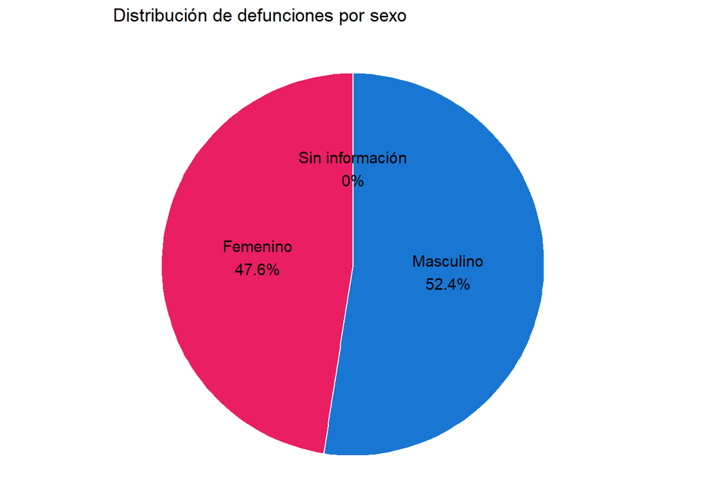

```r
df %>%
  count(SEXO) %>%
  mutate(
    Porcentaje = round(n / sum(n) * 100, 1),
    etiqueta   = paste0(SEXO, "\n", Porcentaje, "%")
  ) %>%
  ggplot(aes(x = "", y = n, fill = SEXO)) +
  geom_col(width = 1, color = "white") +
  coord_polar(theta = "y") +
  geom_text(aes(label = etiqueta),
            position = position_stack(vjust = 0.5), size = 4) +
  scale_fill_manual(values = c("Masculino"       = "#1976D2",
                               "Femenino"        = "#E91E63",
                               "Sin información" = "#9E9E9E")) +
  labs(title = "Distribución de defunciones por sexo") +
  theme_void() +
  theme(legend.position = "none")
```

> El sexo masculino concentra la mayoría de las defunciones registradas en el período. Esta sobremortalidad masculina es un fenómeno ampliamente documentado en Colombia y en América Latina, y responde a dos factores principales: una mayor exposición a causas externas de muerte (homicidios, accidentes de tránsito) en edades jóvenes, y una menor adherencia a controles preventivos de salud en edades adultas.

### 4.2.2 Tipo de defunción

```r
df %>%
  count(TIPO_DEFUN) %>%
  mutate(Porcentaje = round(n / sum(n) * 100, 2)) %>%
  arrange(desc(n)) %>%
  kable(
    caption   = "Distribución por tipo de defunción",
    col.names = c("Tipo", "Defunciones", "Porcentaje (%)"),
    align     = c("l", "r", "r")
  ) %>%
  kable_styling(bootstrap_options = c("striped", "hover"), full_width = FALSE)
```

Distribución por tipo de defunción

| Tipo | Defunciones | Porcentaje (%) |
| --- | --- | --- |
| No natural | 145377 | 100 |

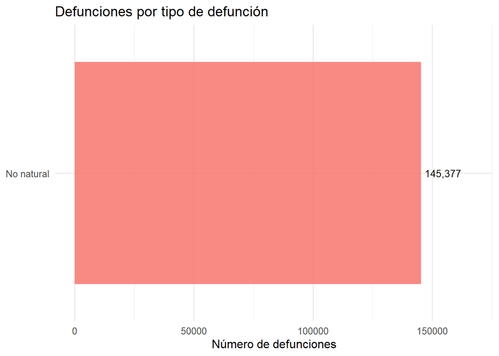

```r
df %>%
  count(TIPO_DEFUN) %>%
  ggplot(aes(x = reorder(TIPO_DEFUN, n), y = n, fill = TIPO_DEFUN)) +
  geom_col(show.legend = FALSE, alpha = 0.85) +
  geom_text(aes(label = comma(n)), hjust = -0.1, size = 3.5) +
  coord_flip() +
  ylim(0, max(table(df$TIPO_DEFUN)) * 1.15) +
  labs(
    title = "Defunciones por tipo de defunción",
    x     = NULL,
    y     = "Número de defunciones"
  ) +
  theme_minimal(base_size = 12)
```

### 4.2.3 Estado civil

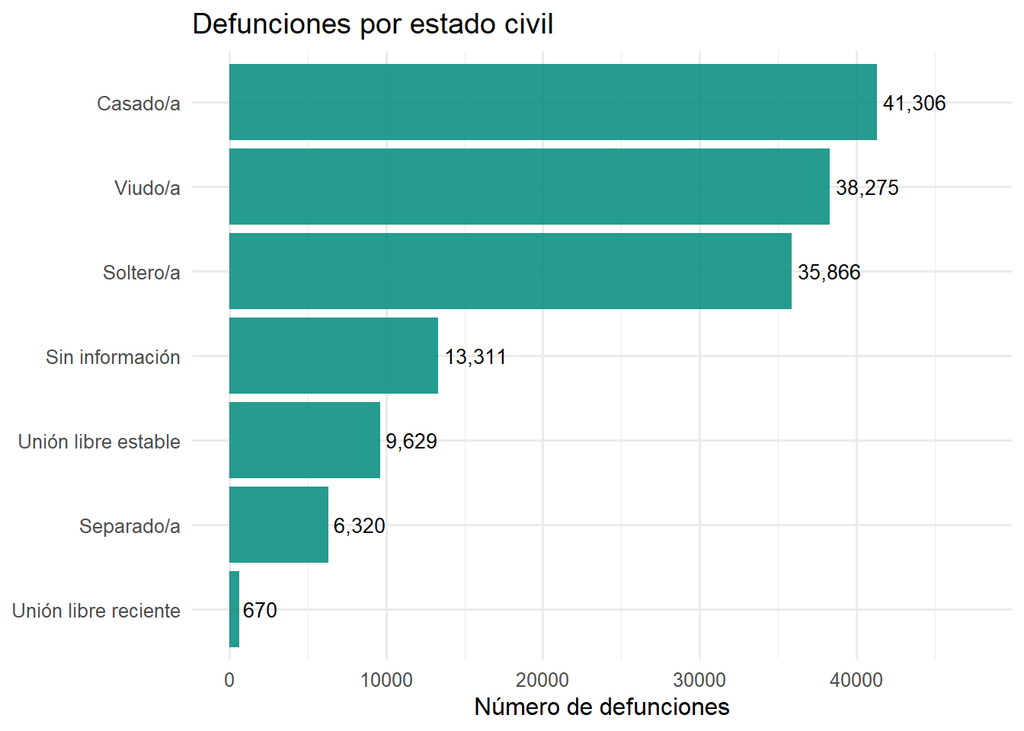

```r
df %>%
  count(EST_CIVIL) %>%
  mutate(Porcentaje = round(n / sum(n) * 100, 2)) %>%
  arrange(desc(n)) %>%
  ggplot(aes(x = reorder(EST_CIVIL, n), y = n)) +
  geom_col(fill = "#00897B", alpha = 0.85) +
  geom_text(aes(label = comma(n)), hjust = -0.1, size = 3.5) +
  coord_flip() +
  ylim(0, max(table(df$EST_CIVIL)) * 1.15) +
  labs(
    title = "Defunciones por estado civil",
    x     = NULL,
    y     = "Número de defunciones"
  ) +
  theme_minimal(base_size = 12)
```

> La distribución por estado civil refleja en parte la estructura demográfica de la ciudad. La prevalencia de fallecidos **solteros** puede estar asociada a muertes en edades jóvenes (causas violentas), mientras que la alta frecuencia de **viudos/as** es coherente con la mortalidad en adultos mayores.

### 4.2.4 Nivel educativo

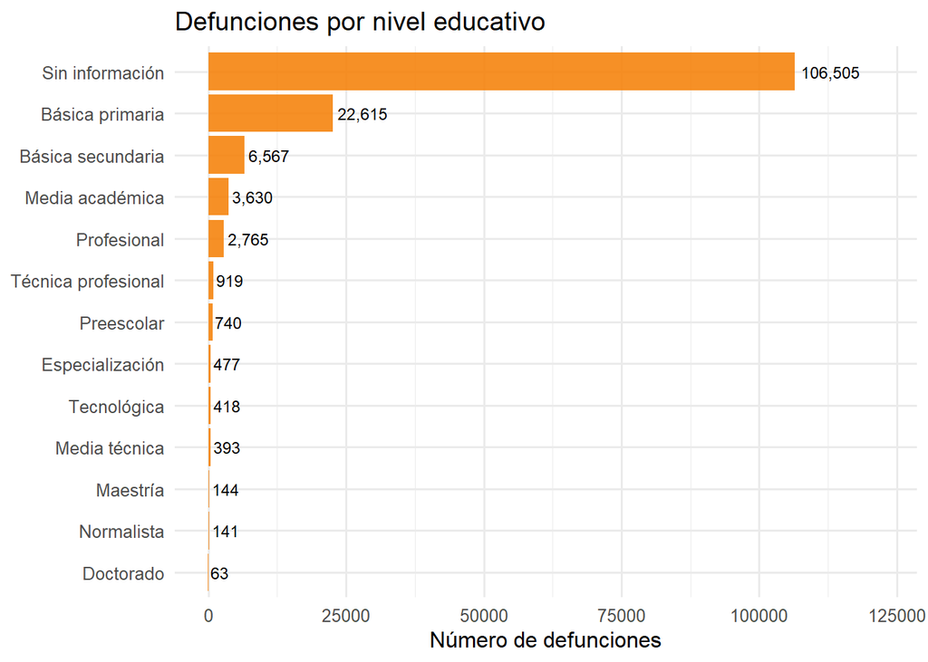

```r
df %>%
  count(NIVEL_EDU) %>%
  mutate(Porcentaje = round(n / sum(n) * 100, 2)) %>%
  arrange(desc(n)) %>%
  ggplot(aes(x = reorder(NIVEL_EDU, n), y = n)) +
  geom_col(fill = "#F57C00", alpha = 0.85) +
  geom_text(aes(label = comma(n)), hjust = -0.1, size = 3.2) +
  coord_flip() +
  ylim(0, max(table(df$NIVEL_EDU)) * 1.15) +
  labs(
    title = "Defunciones por nivel educativo",
    x     = NULL,
    y     = "Número de defunciones"
  ) +
  theme_minimal(base_size = 12)
```

> El nivel educativo de los fallecidos muestra que la **básica primaria** concentra una proporción elevada de registros, lo que está relacionado con la estructura etaria de la mortalidad: las personas de mayor edad alcanzaron niveles educativos más bajos debido a las condiciones históricas de acceso a la educación en décadas pasadas.

### 4.2.5 Régimen de seguridad social

```r
df %>%
  count(SEG_SOCIAL) %>%
  mutate(Porcentaje = round(n / sum(n) * 100, 2)) %>%
  arrange(desc(n)) %>%
  kable(
    caption   = "Distribución por régimen de seguridad social",
    col.names = c("Régimen", "Defunciones", "Porcentaje (%)"),
    align     = c("l", "r", "r")
  ) %>%
  kable_styling(bootstrap_options = c("striped", "hover"), full_width = FALSE)
```

Distribución por régimen de seguridad social

| Régimen | Defunciones | Porcentaje (%) |
| --- | --- | --- |
| Contributivo | 84541 | 58.15 |
| Subsidiado | 49228 | 33.86 |
| Excepción | 5688 | 3.91 |
| Vinculado | 3468 | 2.39 |
| Sin información | 1740 | 1.20 |
| Particular | 712 | 0.49 |

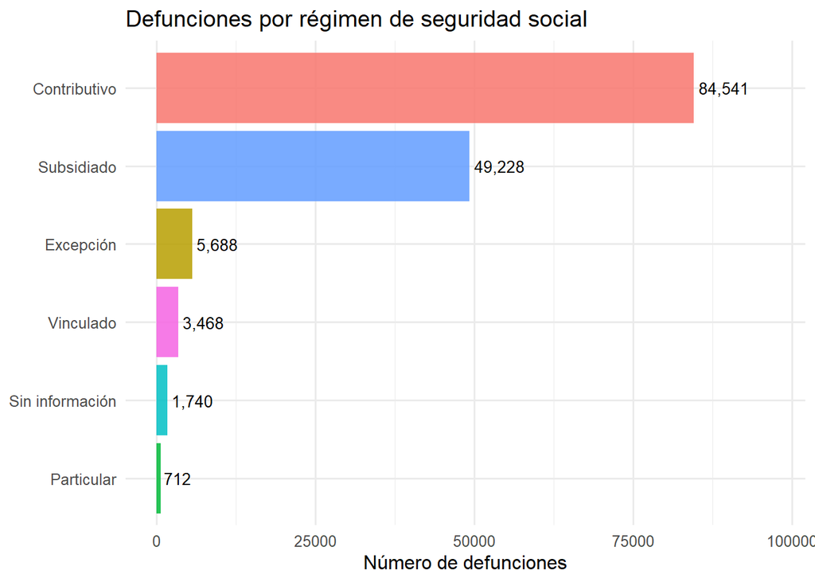

```r
df %>%
  count(SEG_SOCIAL) %>%
  ggplot(aes(x = reorder(SEG_SOCIAL, n), y = n, fill = SEG_SOCIAL)) +
  geom_col(show.legend = FALSE, alpha = 0.85) +
  geom_text(aes(label = comma(n)), hjust = -0.1, size = 3.5) +
  coord_flip() +
  ylim(0, max(table(df$SEG_SOCIAL)) * 1.15) +
  labs(
    title = "Defunciones por régimen de seguridad social",
    x     = NULL,
    y     = "Número de defunciones"
  ) +
  theme_minimal(base_size = 12)
```

> Los regímenes **contributivo** y **subsidiado** concentran la mayor parte de los registros, en correspondencia con la estructura del Sistema General de Seguridad Social en Salud de Colombia. La presencia del régimen **vinculado** (personas sin afiliación formal) es un indicador de vulnerabilidad socioeconómica.

### 4.2.6 Grupo etario quinquenal

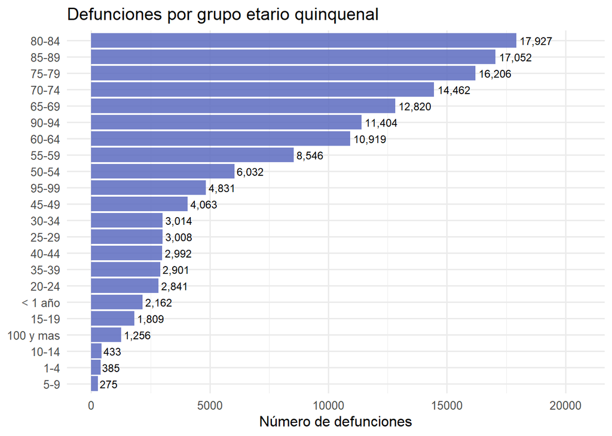

```r
df %>%
  filter(!is.na(ETAREO_QUIN), ETAREO_QUIN != "Sin informacion") %>%
  count(ETAREO_QUIN) %>%
  ggplot(aes(x = reorder(ETAREO_QUIN, n), y = n)) +
  geom_col(fill = "#5C6BC0", alpha = 0.85) +
  geom_text(aes(label = comma(n)), hjust = -0.1, size = 3.2) +
  coord_flip() +
  ylim(0, max(table(df$ETAREO_QUIN)) * 1.15) +
  labs(
    title = "Defunciones por grupo etario quinquenal",
    x     = NULL,
    y     = "Número de defunciones"
  ) +
  theme_minimal(base_size = 12)
```

> Los grupos etarios de **75 años y más** concentran la mayor carga de defunciones, confirmando el perfil de mortalidad propio de una ciudad con expectativa de vida relativamente alta. Se observa también un pequeño pico en los grupos de 20–34 años, asociado principalmente a muertes violentas.

# 5 Análisis Temporal

## 5.1 Evolución anual de defunciones

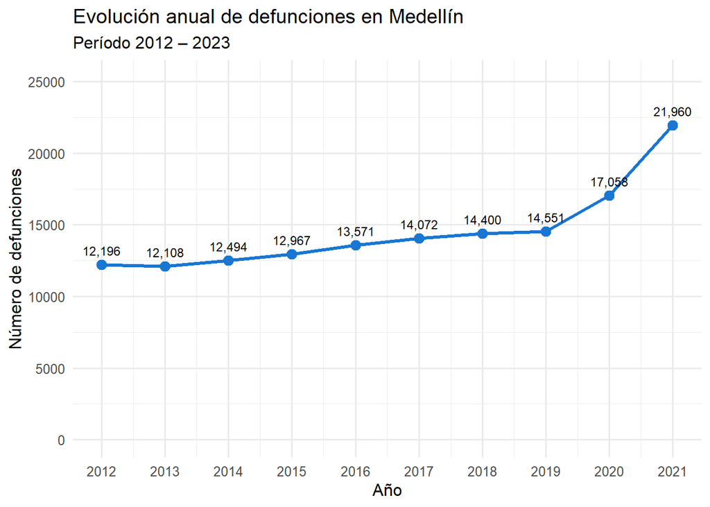

```r
df %>%
  count(ANO) %>%
  ggplot(aes(x = ANO, y = n)) +
  geom_line(color = "#1976D2", linewidth = 1.2) +
  geom_point(color = "#1976D2", size = 3) +
  geom_text(aes(label = comma(n)), vjust = -1, size = 3.2) +
  scale_x_continuous(breaks = seq(2012, 2023, 1)) +
  ylim(0, max(table(df$ANO)) * 1.15) +
  labs(
    title    = "Evolución anual de defunciones en Medellín",
    subtitle = "Período 2012 – 2023",
    x        = "Año",
    y        = "Número de defunciones"
  ) +
  theme_minimal(base_size = 12)
```

> La tendencia general de defunciones muestra una evolución que puede dividirse en dos momentos. Entre 2012 y 2019 se observa una trayectoria relativamente estable, con variaciones moderadas entre años. El año **2020** marca un quiebre significativo al alza, consistente con el impacto de la pandemia de COVID-19.

## 5.2 Estacionalidad mensual

[figure not shown]

```r
df %>%
  count(MES) %>%
  mutate(MES_NOM = factor(MES, levels = 1:12,
                          labels = c("Ene","Feb","Mar","Abr","May","Jun",
                                     "Jul","Ago","Sep","Oct","Nov","Dic"))) %>%
  ggplot(aes(x = MES_NOM, y = n, group = 1)) +
  geom_line(color = "#7B1FA2", linewidth = 1.2) +
  geom_point(color = "#7B1FA2", size = 3) +
  geom_text(aes(label = comma(n)), vjust = -1, size = 3.2) +
  ylim(0, max(table(df$MES)) * 1.15) +
  labs(
    title = "Estacionalidad mensual de defunciones (todos los años)",
    x     = "Mes",
    y     = "Número de defunciones"
  ) +
  theme_minimal(base_size = 12)
```

## 5.3 Heatmap año × mes

[figure not shown]

```r
df %>%
  count(ANO, MES) %>%
  mutate(MES_NOM = factor(MES, levels = 1:12,
                          labels = c("Ene","Feb","Mar","Abr","May","Jun",
                                     "Jul","Ago","Sep","Oct","Nov","Dic"))) %>%
  ggplot(aes(x = MES_NOM, y = factor(ANO), fill = n)) +
  geom_tile(color = "white", linewidth = 0.4) +
  geom_text(aes(label = comma(n)), size = 2.8) +
  scale_fill_gradient(low = "#E3F2FD", high = "#0D47A1",
                      name = "Defunciones") +
  labs(
    title = "Mapa de calor: defunciones por año y mes",
    x     = "Mes",
    y     = "Año"
  ) +
  theme_minimal(base_size = 12)
```

## 5.4 Defunciones por tipo a lo largo del tiempo

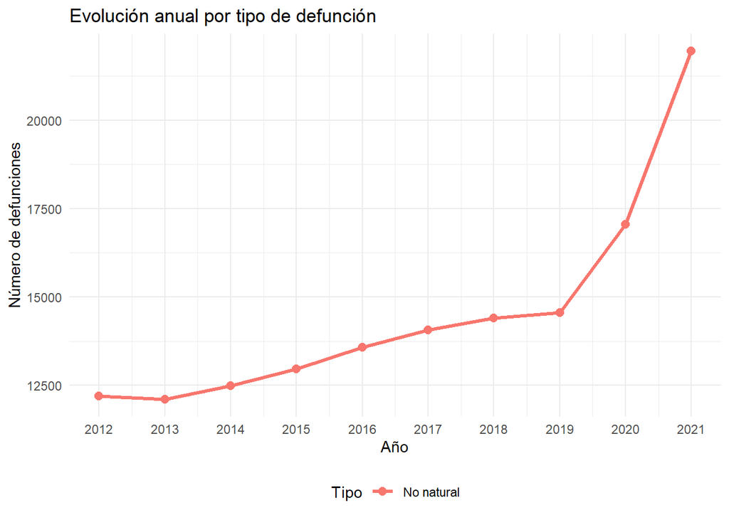

```r
df %>%
  count(ANO, TIPO_DEFUN) %>%
  ggplot(aes(x = ANO, y = n, color = TIPO_DEFUN, group = TIPO_DEFUN)) +
  geom_line(linewidth = 1.1) +
  geom_point(size = 2.5) +
  scale_x_continuous(breaks = seq(2012, 2023, 1)) +
  labs(
    title = "Evolución anual por tipo de defunción",
    x     = "Año",
    y     = "Número de defunciones",
    color = "Tipo"
  ) +
  theme_minimal(base_size = 11) +
  theme(legend.position = "bottom")
```

## 5.5 Defunciones por sexo a lo largo del tiempo

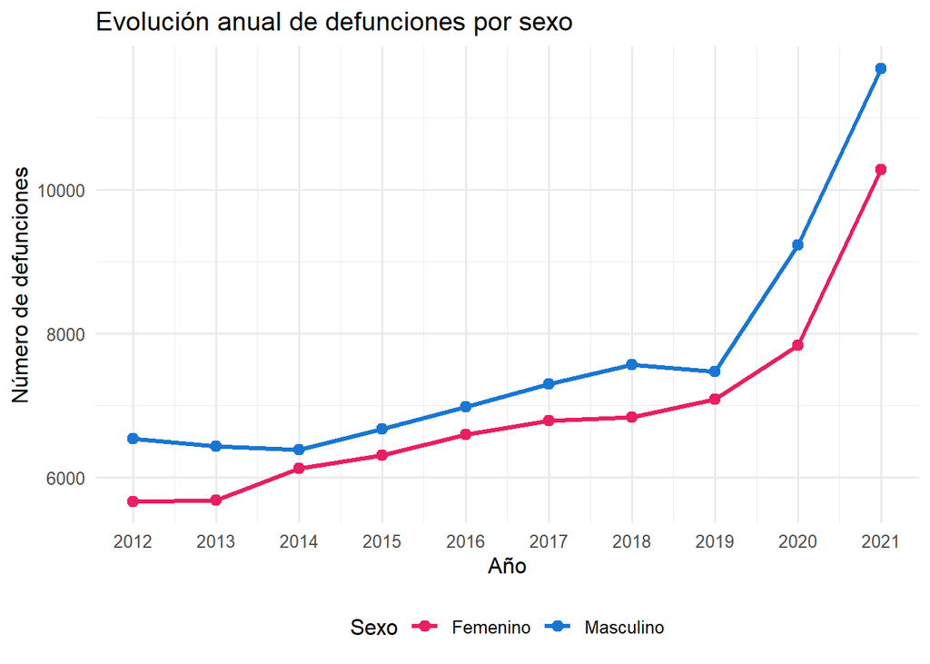

```r
df %>%
  filter(SEXO != "Sin información") %>%
  count(ANO, SEXO) %>%
  ggplot(aes(x = ANO, y = n, color = SEXO, group = SEXO)) +
  geom_line(linewidth = 1.1) +
  geom_point(size = 2.5) +
  scale_x_continuous(breaks = seq(2012, 2023, 1)) +
  scale_color_manual(values = c("Masculino" = "#1976D2",
                                "Femenino"  = "#E91E63")) +
  labs(
    title = "Evolución anual de defunciones por sexo",
    x     = "Año",
    y     = "Número de defunciones",
    color = "Sexo"
  ) +
  theme_minimal(base_size = 12) +
  theme(legend.position = "bottom")
```

## 5.6 Promedio mensual por año

```r
df %>%
  count(ANO, MES) %>%
  group_by(ANO) %>%
  summarise(
    Promedio_mensual = round(mean(n), 1),
    Maximo_mensual   = max(n),
    Minimo_mensual   = min(n)
  ) %>%
  kable(
    caption   = "Promedio, máximo y mínimo mensual de defunciones por año",
    col.names = c("Año", "Promedio mensual", "Máximo mensual", "Mínimo mensual"),
    align     = c("l", "r", "r", "r")
  ) %>%
  kable_styling(bootstrap_options = c("striped", "hover"), full_width = FALSE)
```

Promedio, máximo y mínimo mensual de defunciones por año

| Año | Promedio mensual | Máximo mensual | Mínimo mensual |
| --- | --- | --- | --- |
| 2012 | 1016.3 | 1097 | 908 |
| 2013 | 1009.0 | 1102 | 876 |
| 2014 | 1041.2 | 1161 | 928 |
| 2015 | 1080.6 | 1256 | 994 |
| 2016 | 1130.9 | 1289 | 990 |
| 2017 | 1172.7 | 1266 | 1091 |
| 2018 | 1200.0 | 1428 | 969 |
| 2019 | 1212.6 | 1294 | 1098 |
| 2020 | 1421.5 | 1982 | 995 |
| 2021 | 1830.0 | 2998 | 1353 |

# 6 Análisis de Causas de Muerte

## 6.1 Top 20 causas básicas (CIE-10)

```r
df %>%
  filter(!is.na(N_BAS1), N_BAS1 != "Sin informacion") %>%
  count(C_BAS1, N_BAS1) %>%
  arrange(desc(n)) %>%
  slice_head(n = 20) %>%
  kable(
    caption   = "Top 20 causas básicas de muerte (CIE-10)",
    col.names = c("Código CIE-10", "Causa", "Defunciones"),
    align     = c("l", "l", "r")
  ) %>%
  kable_styling(
    bootstrap_options = c("striped", "hover", "condensed"),
    full_width        = TRUE,
    font_size         = 11
  )
```

Top 20 causas básicas de muerte (CIE-10)

| Código CIE-10 | Causa | Defunciones |
| --- | --- | --- |
| I219 | INFARTO AGUDO DEL MIOCARDIO SIN OTRA ESPECIFICACION | 11996 |
| U071 | COVID-19, virus identificado | 8190 |
| I219 | Infarto agudo del miocardio, sin otra especificación | 5245 |
| C349 | TUMOR MALIGNO DE LOS BRONQUIOS O DEL PULMON PARTE NO ESPECIFICADA | 3807 |
| J189 | NEUMONIA NO ESPECIFICADA | 2989 |
| J449 | ENFERMEDAD PULMONAR OBSTRUCTIVA CRONICA NO ESPECIFICADA | 2574 |
| J440 | ENFERMEDAD PULMONAR OBSTRUCTIVA CRONICA CON INFECCION AGUDA DE LAS VIAS RESPIRATORIAS INFERIORES | 2519 |
| C169 | TUMOR MALIGNO DEL ESTOMAGO PARTE NO ESPECIFICADA | 2194 |
| X954 | AGRESION CON DISPARO DE OTRAS ARMAS DE FUEGO Y LAS NO ESPECIFICADAS: CALLES Y CARRETERAS | 2084 |
| C509 | TUMOR MALIGNO DE LA MAMA PARTE NO ESPECIFICADA | 1667 |
| C349 | Tumor maligno de los bronquios o del pulmón, parte no especificada | 1579 |
| I10 | Hipertensión esencial (primaria) | 1554 |
| C189 | TUMOR MALIGNO DEL COLON PARTE NO ESPECIFICADA | 1494 |
| N390 | INFECCION DE VIAS URINARIAS SITIO NO ESPECIFICADO | 1479 |
| I10 | HIPERTENSION ESENCIAL (PRIMARIA) | 1435 |
| J449 | Enfermedad pulmonar obstructiva crónica, no especificada | 1363 |
| C61 | TUMOR MALIGNO DE LA PROSTATA | 1296 |
| I679 | ENFERMEDAD CEREBROVASCULAR NO ESPECIFICADA | 1276 |
| C259 | TUMOR MALIGNO DEL PANCREAS PARTE NO ESPECIFICADA | 1176 |
| I110 | ENFERMEDAD CARDIACA HIPERTENSIVA CON INSUFICIENCIA CARDIACA (CONGESTIVA) | 987 |

[figure not shown]

```r
df %>%
  filter(!is.na(N_BAS1), N_BAS1 != "Sin informacion") %>%
  count(N_BAS1) %>%
  slice_max(n, n = 15) %>%
  ggplot(aes(x = reorder(N_BAS1, n), y = n)) +
  geom_col(fill = "#C62828", alpha = 0.85) +
  geom_text(aes(label = comma(n)), hjust = -0.1, size = 3) +
  coord_flip() +
  ylim(0, max(count(df, N_BAS1)$n) * 1.15) +
  labs(
    title = "Top 15 causas básicas de muerte",
    x     = NULL,
    y     = "Número de defunciones"
  ) +
  theme_minimal(base_size = 11)
```

## 6.2 Grupos OPS

```r
df %>%
  filter(!is.na(NOM_667_OPS_GRUPO),
         NOM_667_OPS_GRUPO != "Sin informacion") %>%
  count(NOM_667_OPS_GRUPO) %>%
  arrange(desc(n)) %>%
  mutate(Porcentaje = round(n / sum(n) * 100, 2)) %>%
  kable(
    caption   = "Defunciones por grupo OPS",
    col.names = c("Grupo OPS", "Defunciones", "Porcentaje (%)"),
    align     = c("l", "r", "r")
  ) %>%
  kable_styling(bootstrap_options = c("striped", "hover"), full_width = FALSE)
```

Defunciones por grupo OPS

| Grupo OPS | Defunciones | Porcentaje (%) |
| --- | --- | --- |
| Enfermedades del sistema circulatorio | 41337 | 28.43 |
| Neoplasias (Tumores) | 34857 | 23.98 |
| Todas las demas enfermedades | 33785 | 23.24 |
| Enfermedades Transmisibles | 19070 | 13.12 |
| Causas externas | 14462 | 9.95 |
| Ciertas afecciones originadas en el periodo perinatal | 1121 | 0.77 |
| Signos sintomas y afecciones mal definidas | 745 | 0.51 |

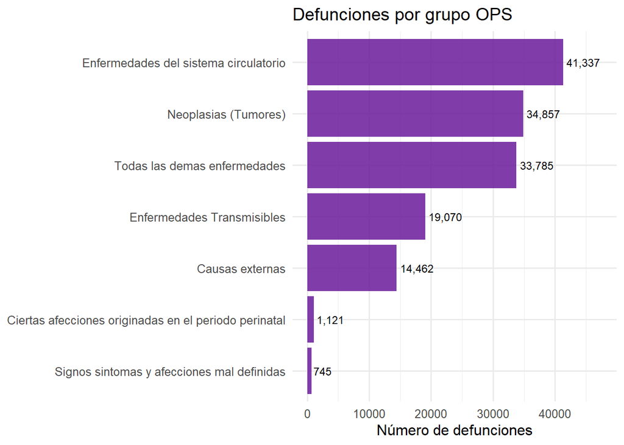

```r
df %>%
  filter(!is.na(NOM_667_OPS_GRUPO),
         NOM_667_OPS_GRUPO != "Sin informacion") %>%
  count(NOM_667_OPS_GRUPO) %>%
  ggplot(aes(x = reorder(NOM_667_OPS_GRUPO, n), y = n)) +
  geom_col(fill = "#6A1B9A", alpha = 0.85) +
  geom_text(aes(label = comma(n)), hjust = -0.1, size = 3.2) +
  coord_flip() +
  ylim(0, max(count(df, NOM_667_OPS_GRUPO)$n) * 1.15) +
  labs(
    title = "Defunciones por grupo OPS",
    x     = NULL,
    y     = "Número de defunciones"
  ) +
  theme_minimal(base_size = 12)
```

> La clasificación OPS agrupa las causas de muerte en grandes categorías comparables internacionalmente. El dominio de las **enfermedades crónicas no transmisibles** (circulatorias, neoplasias, respiratorias) sobre las enfermedades transmisibles señala que Medellín ha completado en gran medida su transición epidemiológica.

## 6.3 Subcategorías OPS

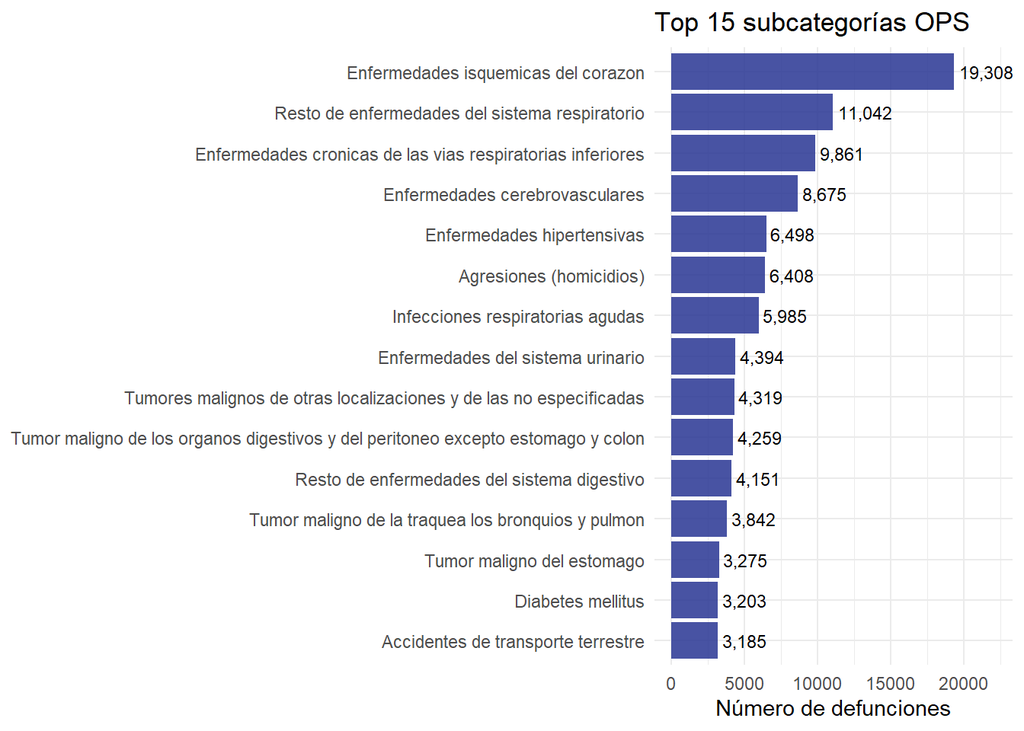

```r
df %>%
  filter(!is.na(NOM_667_OPS_SUBC),
         NOM_667_OPS_SUBC != "Sin informacion") %>%
  count(NOM_667_OPS_SUBC) %>%
  slice_max(n, n = 15) %>%
  ggplot(aes(x = reorder(NOM_667_OPS_SUBC, n), y = n)) +
  geom_col(fill = "#283593", alpha = 0.85) +
  geom_text(aes(label = comma(n)), hjust = -0.1, size = 3) +
  coord_flip() +
  ylim(0, max(count(df, NOM_667_OPS_SUBC)$n) * 1.15) +
  labs(
    title = "Top 15 subcategorías OPS",
    x     = NULL,
    y     = "Número de defunciones"
  ) +
  theme_minimal(base_size = 11)
```

## 6.4 Evolución anual de grupos OPS

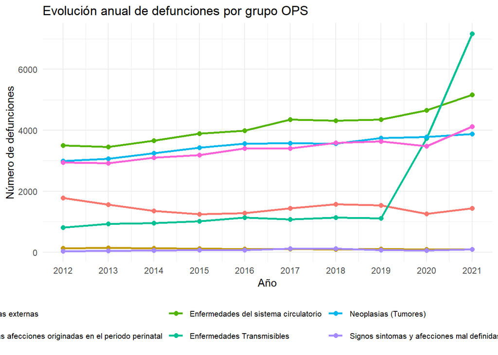

```r
df %>%
  filter(!is.na(NOM_667_OPS_GRUPO),
         NOM_667_OPS_GRUPO != "Sin informacion") %>%
  count(ANO, NOM_667_OPS_GRUPO) %>%
  ggplot(aes(x = ANO, y = n,
             color = NOM_667_OPS_GRUPO,
             group = NOM_667_OPS_GRUPO)) +
  geom_line(linewidth = 0.9) +
  geom_point(size = 2) +
  scale_x_continuous(breaks = seq(2012, 2023, 1)) +
  labs(
    title  = "Evolución anual de defunciones por grupo OPS",
    x      = "Año",
    y      = "Número de defunciones",
    color  = "Grupo OPS"
  ) +
  theme_minimal(base_size = 11) +
  theme(legend.position = "bottom",
        legend.text     = element_text(size = 8))
```

# 7 Análisis Territorial

## 7.1 Defunciones por comuna

```r
df %>%
  filter(!is.na(COMUNA_RES), COMUNA_RES != "Sin informacion") %>%
  count(COMUNA_RES) %>%
  arrange(desc(n)) %>%
  mutate(Porcentaje = round(n / sum(n) * 100, 2)) %>%
  kable(
    caption   = "Defunciones por comuna de residencia",
    col.names = c("Comuna", "Defunciones", "Porcentaje (%)"),
    align     = c("l", "r", "r")
  ) %>%
  kable_styling(
    bootstrap_options = c("striped", "hover", "condensed"),
    full_width        = FALSE
  ) %>%
  scroll_box(height = "400px")
```

Defunciones por comuna de residencia

| Comuna | Defunciones | Porcentaje (%) |
| --- | --- | --- |
| 16 Belen | 13596 | 9.64 |
| 04 Aranjuez | 9617 | 6.82 |
| 11 Laureles | 9545 | 6.77 |
| 03 Manrique | 9521 | 6.75 |
| 10 La Candelaria | 9279 | 6.58 |
| 06 Doce De Octubre | 8902 | 6.31 |
| 07 Robledo | 8680 | 6.15 |
| 09 Buenos Aires | 8668 | 6.14 |
| 13 San Javier | 8312 | 5.89 |
| 08 Villa Hermosa | 8179 | 5.80 |
| 05 Castilla | 7600 | 5.39 |
| 12 La America | 6755 | 4.79 |
| 01 Popular | 6484 | 4.60 |
| 14 El Poblado | 6157 | 4.36 |
| 02 Santa Cruz | 5833 | 4.13 |
| 15 Guayabal | 4528 | 3.21 |
| 80 Corregimiento de San Antonio de Prado | 3642 | 2.58 |
| 60 Corregimiento de San Cristobal | 3508 | 2.49 |
| 70 Corregimiento de Altavista | 1348 | 0.96 |
| 90 Corregimiento de Santa Elena | 655 | 0.46 |
| 50 Corregimiento de Palmitas | 277 | 0.20 |

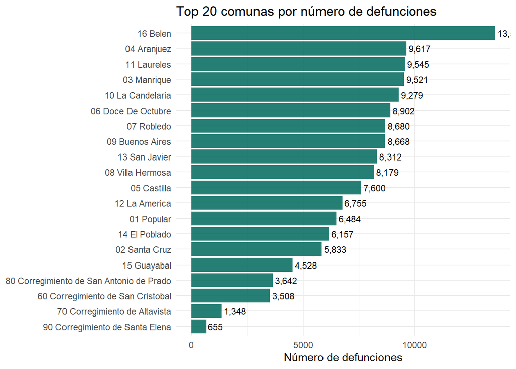

```r
df %>%
  filter(!is.na(COMUNA_RES), COMUNA_RES != "Sin informacion") %>%
  count(COMUNA_RES) %>%
  slice_max(n, n = 20) %>%
  ggplot(aes(x = reorder(COMUNA_RES, n), y = n)) +
  geom_col(fill = "#00695C", alpha = 0.85) +
  geom_text(aes(label = comma(n)), hjust = -0.1, size = 3) +
  coord_flip() +
  labs(
    title = "Top 20 comunas por número de defunciones",
    x     = NULL,
    y     = "Número de defunciones"
  ) +
  theme_minimal(base_size = 11)
```